# Homework #4

3/1/2018

## Chick weights

```r
library(tidyverse)
data("ChickWeight")
```

The `ChickWeight` data set is part of the base package `datasets`. See `?ChickWeight` for details on the data. For all of the questions use `dplyr` functions whenever possible.

1. Download the RMarkdown file with these homework instructions to use as a template for your work. Make sure to replace “Your Name” in the YAML with your name.
2. Get a frequency breakdown of the number of chicks, their average weight and the standard deviation of the weights in each of the diets at the start of the study.
- The following code shows the number of chicks on each diet first then provides the requested summaries

```r
summary(ChickWeight$Diet)
```

```
##   1   2   3   4
## 220 120 120 118
```

```r
ChickWeight %>% group_by(Diet) %>% filter(Time == 0) %>% summarise(avgWeight = mean(weight), stndrdDeviation = sd(weight))
```

```
## # A tibble: 4 x 3
##   Diet  avgWeight stndrdDeviation
##   <fct>     <dbl>           <dbl>
## 1 1          41.4           0.995
## 2 2          40.7           1.49
## 3 3          40.8           1.03
## 4 4          41.0           1.05
```

0.5 pts of extra credit: construct a ggplot that shows average weights by diet with an interval (shown as a line) of +- the standard deviation around the averages. 3. Each chick should have twelve weight measurements. Use the dplyr package to identify how many chicks have a complete set of weight measurements and how many measurements there are in the incomplete cases. Extract a subset of the data for all chicks with complete information and name the data set `complete`. (Hint: you might want to use mutate to introduce a helper variable consisting of the number of observations)

- There were 5 chicks with incomplete data, which means 45 had a complete set of data.
- The number of values missing are depicted in the final line of code

```r
helper <- ChickWeight %>% count(Chick)
modifiedDF <- merge(ChickWeight, helper, by="Chick")
complete <- filter(modifiedDF, n == 12)
incomplete <- filter(modifiedDF, n != 12)
incomplete %>% count(Chick) %>% mutate(valuesMissing = 12 - nn)
```

```
## # A tibble: 5 x 3
##   Chick    nn valuesMissing
##   <ord> <int>         <dbl>
## 1 18        2         10.0
## 2 16        7          5.00
## 3 15        8          4.00
## 4 8        11          1.00
## 5 44       10          2.00
```

4. In the complete data set introduce a new variable that measures the current weight difference compared to day 0. Name this variable `weightgain`.

```r
complete <- spread(complete, Time, weight)
complete <- complete %>% mutate(weightgain = `21`-`0`)
```

5. Use ggplot2 to create side-by-side boxplots of `weightgain` by `Diet` for day 21. Describe the relationship in 2-3 sentences. Change the order of the categories in the Diet variable such that the boxplots are ordered by median `weightgain`.
- The relationship show that from diet 1-3 the median weight increases then in diet four the median drops off a little bit from three, but it is still higher than diet 2. The range of weight gain in diets 1 and 3 are very similar, the range of weight gain for diet 2 is the greatest, and the range of diet 4 is the smallest. It is worth noting that while diet four does not have the highest weight gain it does have the highest lowest weight gain.

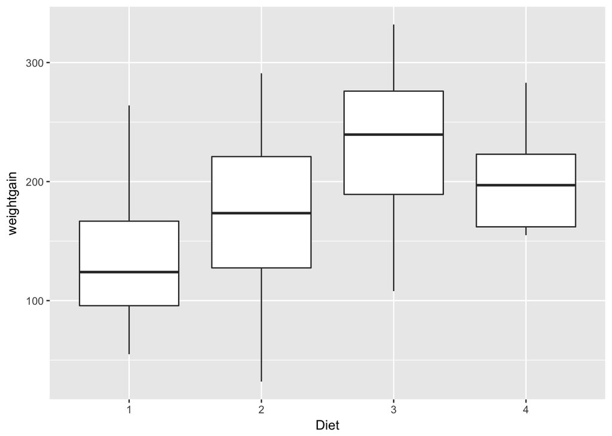

```r
complete %>% ggplot(aes(x= Diet, y = weightgain)) + geom_boxplot()
```

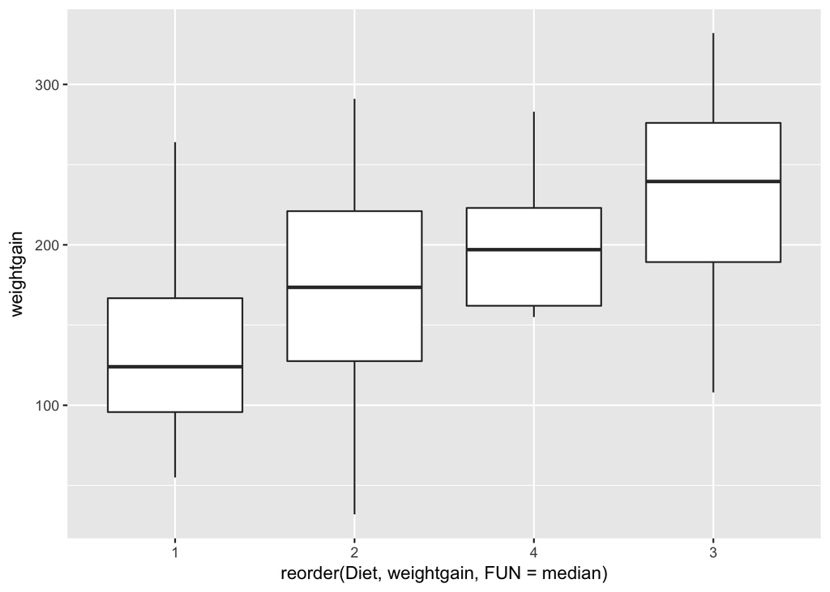

```r
complete %>% ggplot(aes(x= reorder(Diet, weightgain, FUN = median), y = weightgain)) + geom_boxplot()
```

Note: your submission is supposed to be fully reproducible, i.e. the TA and I will ‘knit’ your submission in RStudio.

For the submission: submit your solution in an R Markdown file and (just for insurance) submit the corresponding html (or Word) file with it.